# 1 Data wrangling and exploratory steps

Data processing for Dollinger’s survey work on CanE lg. attitudes

Authors

Affiliations

Lars Hinrichs

The University of Texas at Austin

Stefan Dollinger

University of British Columbia

## 1 Data prep

Here is a preview of the data.

```
# A tibble: 2,966 × 37
   region region_previous province cool  multiling umultiling comf_non_eng media
   <fct>  <chr>           <fct>    <chr> <chr>     <chr>      <chr>        <chr>
 1 BC     bc              British… stro… definite… no         <NA>         extr…
 2 BC     bc              British… stro… probably… no         <NA>         impo…
 3 BC     bc              United … stro… probably… no         <NA>         extr…
 4 US     us              British… stro… probably… yes        extremely c… unim…
 5 BC     bc              Quebec   stro… probably… yes        moderately … impo…
 6 other  singapore       British… stro… probably… yes        moderately … unim…
 7 BC     bc              British… stro… probably… no         <NA>         impo…
 8 ON     on              Ontario  agree probably… no         <NA>         impo…
 9 BC     bc              British… agree definite… yes        neither com… <NA>
10 other  <NA>            British… stro… definite… no         <NA>         impo…
# ℹ 2,956 more rows
# ℹ 29 more variables: priv <chr>, st_heard <chr>, st_descr <chr>, zed <chr>,
#   spell <chr>, spell_uni <chr>, distinct <chr>, same_ew <chr>, celebs <chr>,
#   prestige <chr>, rec_cdns <chr>, software <chr>, dictionary <chr>,
#   recog_eh <chr>, cdn_sorry <chr>, engl_able <chr>, fr_able <chr>,
#   ind_able <chr>, beyond_ef <chr>, cdn_way <chr>, age <int>, country <chr>,
#   gender <chr>, edu_comp <chr>, degree_year <chr>, eui <chr>, …
```

Having cleaned the data in other steps, the version I use here has the `region` column cleaned up. Here are the values we have in `region`:

```
# A tibble: 14 × 2
   region     n
   <fct>  <int>
 1 BC       444
 2 AB       506
 3 SK       278
 4 MB       295
 5 ON       520
 6 PE        44
 7 QC       105
 8 NB        36
 9 NS        45
10 NL        42
11 TR        10
12 US       127
13 UK        32
14 other    482
```

…or, sorted by magnitude of n:

```
# A tibble: 14 × 2
   region     n
   <fct>  <int>
 1 ON       520
 2 AB       506
 3 other    482
 4 BC       444
 5 MB       295
 6 SK       278
 7 US       127
 8 QC       105
 9 NS        45
10 PE        44
11 NL        42
12 NB        36
13 UK        32
14 TR        10
```

### 1.1 Data cleaning steps

This, for the record, is the data cleaning procedure that was used.

```r
remove_punctuation_except_intra_word_lowercase <- function(text) {
  # Replace intra-word apostrophes and dashes with placeholders (lowercase only)
  text <- str_replace_all(text, "(?<=[a-z])(['-])(?=[a-z])", "TEMPINTRA\\1")

  # Remove all punctuation (excluding the placeholder)
  text <- str_replace_all(text, "[[:punct:]&&[^A-Z]]", "")

  # Restore intra-word apostrophes and dashes
  text <- str_replace_all(text, "TEMPINTRA(['-])", "\\1")

  # Remove any remaining TEMPINTRA
  text <- str_replace_all(text, "TEMPINTRA", "")

  return(text)
}
```

Also applied the following cleaning steps:

- Clean the `Age` col and make viable as an `integer` col type.
- Apply lower casing to `char` cols.
- Insert NAs instead of blank values in `char` cols.
- Apply the punctuation cleaner fct (defined above) to the cell content.
- Apply `janitor::clean_names()` to the colnames.

```r
df <- df %>%
  mutate(Age = case_match(
    Age,
    "x" ~ NA_character_,
    "14 and under" ~ "01-14",
    .default = Age
  )) %>%
  mutate(Age = str_extract(Age, "\\d+$")) %>%
  mutate(Age = as.integer(Age)) %>%
  mutate(across(where(is.character), str_to_lower)) %>%
  mutate(across(where(is.character), ~na_if(., ""))) %>%
  mutate(across(where(is.character), ~na_if(., " "))) %>%
  mutate(across(where(is.character), ~na_if(., "x"))) %>% #
  mutate(across(where(is.character), ~na_if(., "don't know"))) %>%
  mutate(across(where(is.character), ~str_remove_all(., "\\(.*?\\)"))) %>%
  mutate(across(where(is.character), ~remove_punctuation_except_intra_word_lowercase(.))) %>%
  clean_names()
```

#### 1.1.1 Fix “land” naming error

One of the column names erroneously uses “land” (`live_land`). This neeeds to be renamed as `country`.

At the same time, `live_prov` must be renamed to `province`.

```r
df_cleaned <- df_cleaned %>%
  rename(country = live_land,
         province = live_prov)

df <- df_cleaned
```

## 2 Descriptive stats: `st_heard`

One top important question is **Have you heard of either “Standard Canadian English” or “Canadian Standard English”?**

In the present dataset, it is called `st_heard`.

We start by filtering the data, removing NAs, and obtaining the group total for each region. Then straight into the plotting function.

### 2.1 Complete view

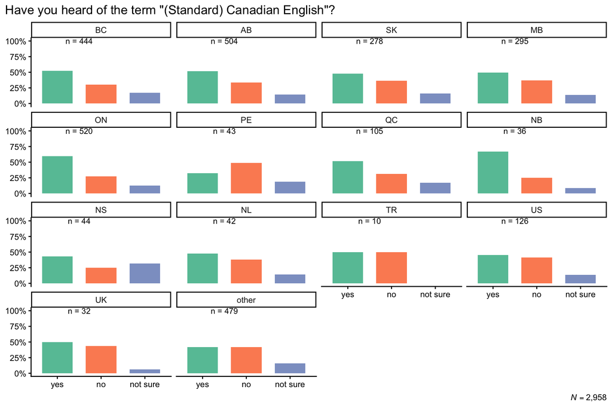

Figure 1

Testing this distribution for significance, we get the following.

```
# A tibble: 13 × 4
# Rowwise:
   region   chi2 p_value significance
   <fct>   <dbl> <chr>   <chr>
 1 BC     26.1   0.0000  "****"
 2 AB     19.2   0.0000  "****"
 3 SK      3.85  0.0499  "*"
 4 MB      5.37  0.0205  "*"
 5 ON     62.2   0.0000  "****"
 6 PE      1.4   0.2367  ""
 7 QC      5.07  0.0244  "*"
 8 NB      6.82  0.0090  "**"
 9 NS      2.13  0.1441  ""
10 NL      0.444 0.5050  ""
11 TR      0     1.0000  ""
12 US      0.229 0.6320  ""
13 UK      0.133 0.7150  ""
```

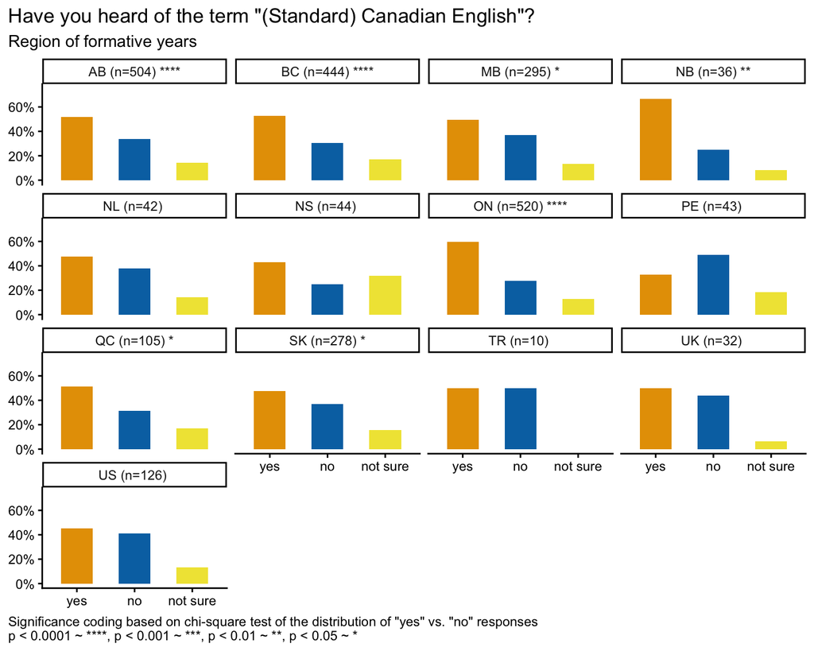

Figure 2

### 2.3 Alternative version

> **Stefan**, Should I exclude the bar where `region` is “other”? Does not seem relevant.

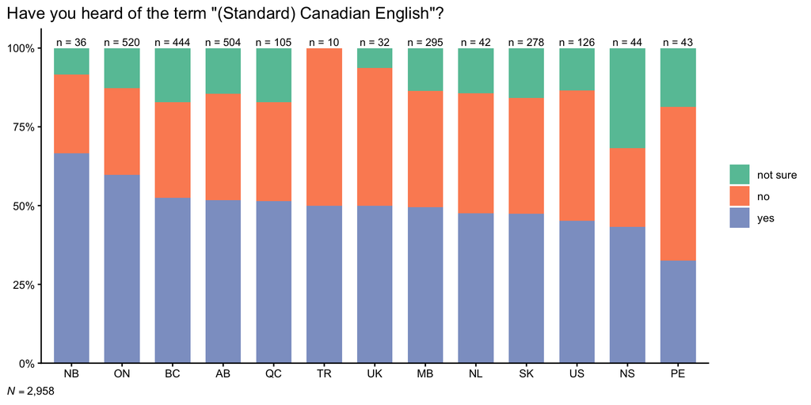

Figure 3

### 2.4 Some bw versions

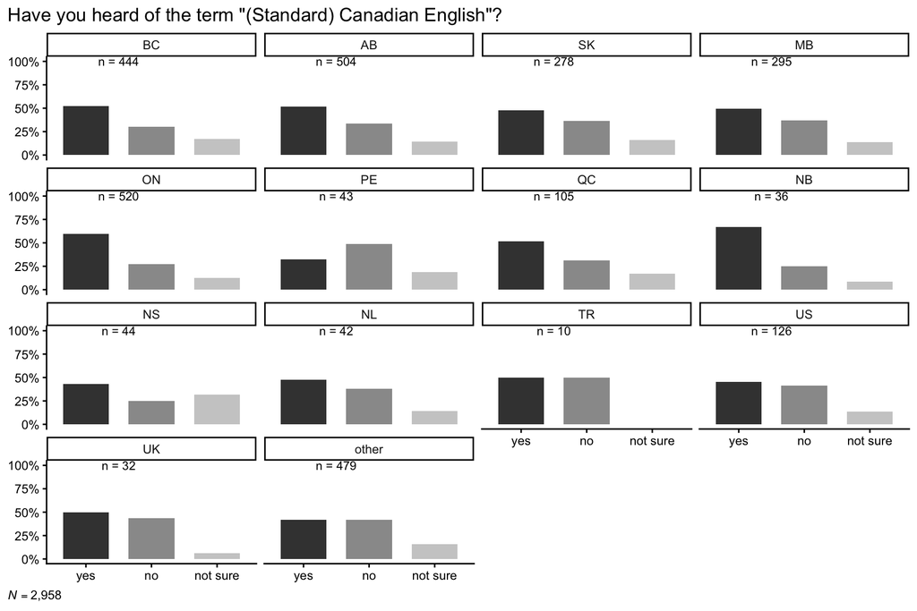

Figure 4

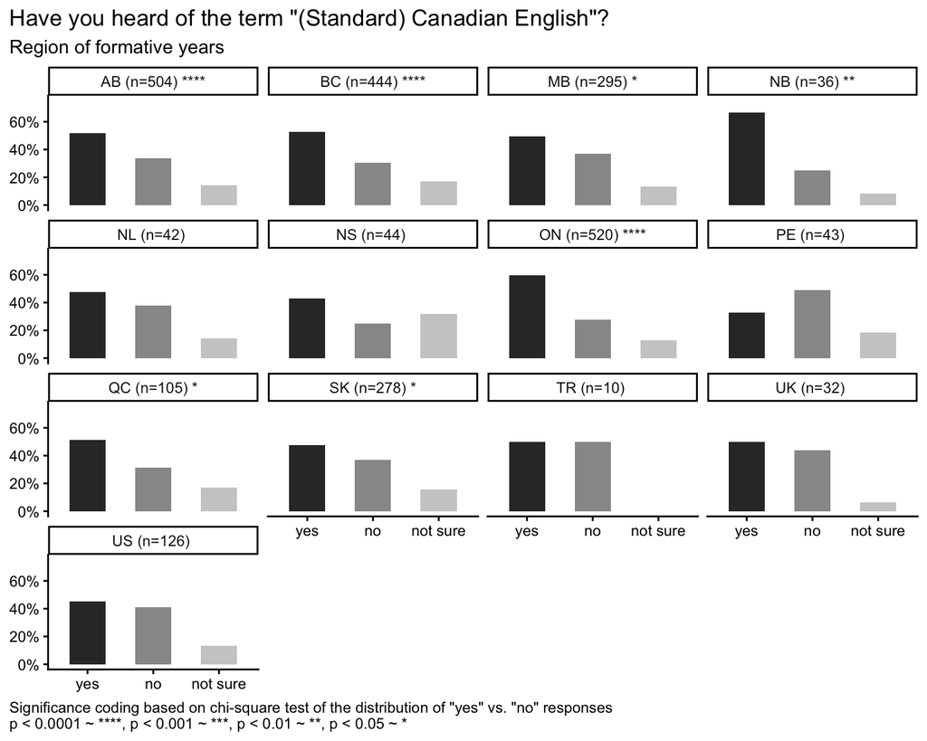

Figure 5

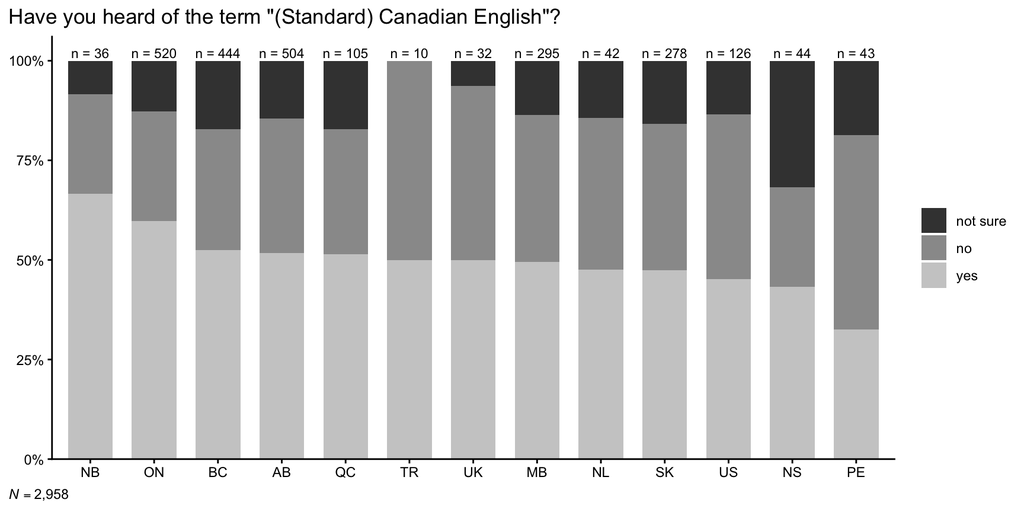

Figure 6

## 3 Next steps

We’ll move on to multivariate in the next document. That means: multiple IVs and a single DV.